# 2. ΒΑΣΙΚΗ ΣΥΝΤΑΞΗ

2.1 Αναγνωριστικά (Identifiers)

2.2 Δεσμευμένες Λέξεις

2.3 Μπλοκ (γραμμών κώδικα) και Εσοχές (Indentation)

2.4 Σπάσιμο γραμμών μέσα σε κώδικα

## 2.1 Αναγνωριστικά (Identifiers)

Ένα **αναγνωριστικό (identifier)** της Python είναι ένα *όνομα* που χρησιμοποιείται για να αναγνωρίζονται τα εξής πράγματα (που θα ορισθούν/συζητηθούν κατά την διάρκεια των μαθημάτων):

- μια μεταβλητή
- μια συνάρτηση
- μια κλάση
- μια μονάδα (module)
- ή ένα αντικείμενο

Ένα αναγνωριστικό γράφεται με τα εξής *συνεχόμενα* σύμβολα:

- τα λατινικά γράμματα, κεφαλαία ή μικρά,
- τον χαρακτήρα υπογράμμισης (underscore)
- τους αριθμούς από 0 ως 9

Κάθε αναγνωριστικό πρέπει:

- να περιλαμβάνει τουλάχιστον ένα (ή περισσότερα) από τα προηγούμενα σύμβολα (αλλά, αν αποτελείται μόνο από ένα σύμβολο, αυτό **δεν** πρέπει να είναι αριθμός!)
- και, σε οποιαδήποτε περίπτωση, **να μην αρχίζει με αριθμό**

## 2.2 Δεσμευμένες Λέξεις

Οι παρακάτω λέξεις δεν μπορούν να χρησιμοποιηθούν ως αναγνωριστικά!

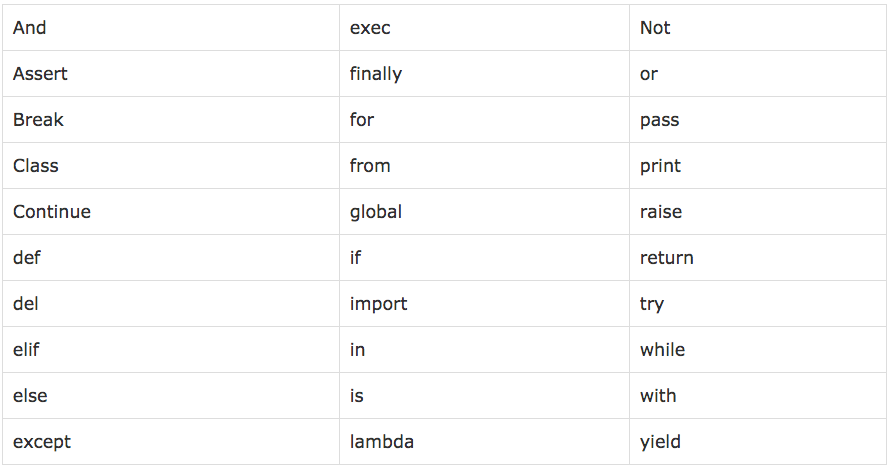

```python
from IPython.display import Image
Image(filename='ReservedWords.png')
```

## 2.3 Μπλοκ (γραμμών κώδικα) και Εσοχές (Indentation)

Ο κώδικας (οι εντολές) στην Python γράφονται σε διακριτά μπλοκ γραμμών. Όταν ένα μπλοκ περιέχει κάποιο άλλο μπλοκ, το δεύτερο πρέπει να γράφεται με εσοχή (indentation) από αριστερά. Σε κάθε διαδοχικό περιεχόμενο μπλοκ προστίθεται η αντίστοιχη εσοχή. Καθώς ο κώδικας εκτελείται, όπως είναι γραμμένος από πάνω (αριστερά) προς τα κάτω (δεξιά), δυο (ή περισσότερα) μπλοκ που το ένα ακολουθεί το άλλο (χωρίς το δεύτερο να περιέχεται στο δεύτερο) γράφονται με τις ίδιες εσοχές (ή και καθόλου, αν αυτά τα μπλοκ δεν περιέχονται σε κανένα άλλο).

Ένα παράδειγμα δομής μπλοκ-εσοχών εδίνεται από το παρακάτω απόσπασμα κώδικα (snippet), που αποτελεί έναν βρόχο (loop) for (όπως θα δούμε στη συνέχεια του μαθήματος):

```python
for i in [1, 2, 3, 4, 5]:
    print i                      # first line in "for i" block
    for j in [1, 2, 3, 4, 5]:
        print j                  # first line in "for j" block
        print i + j              # last line in "for j" block
    print i                      # last line in "for i" block
print "done looping"
```

```
1
1
2
2
3
3
4
4
5
5
6
1
2
1
3
2
4
3
5
4
6
5
7
2
3
1
4
2
5
3
6
4
7
5
8
3
4
1
5
2
6
3
7
4
8
5
9
4
5
1
6
2
7
3
8
4
9
5
10
5
done looping
```

## 2.4 Σπάσιμο γραμμών μέσα σε κώδικα

**Μέσα σε παρενθέσεις ή αγκύλες**, μπορούν να σπάζουν ελεύθερα οι γραμμές του κώδικα χωρίς να λαμβάνονται υπόψη οι εσωχές. Π.χ.:

```python
long_winded_computation = (1 + 2 + 3 + 4 + 5 + 6 + 7 + 8 + 9 + 10 + 11 + 12 +
                           13 + 14 + 15 + 16 + 17 + 18 + 19 + 20)

list_of_lists = [[1, 2, 3], [4, 5, 6], [7, 8, 9]]

easier_to_read_list_of_lists = [ [1, 2, 3],
                                 [4, 5, 6],
                                 [7, 8, 9] ]
```

**Έξω από παρενθέσεις ή αγκύλες**, το σπάσιμο μιας γραμμής γίνεται με το σύμβολο "\". Π.χ.:

```python
two_plus_three = 2 + \
                 3
```